# MigParl Corpus Data Report

2020-01-27

## Introduction

This document is parametrized and can be generated from the command line, passing the corpus to report on as a parameter, as follows.

```bash
Rscript -e 'rmarkdown::render(input = "data_report_template.Rmd", output_format = "html_document", output_file = "data_report_be.html", params = list(target = "MIGPARL", print_out = "TRUE"))'
```

## Getting Started

```r
library(data.table)
```

```
## [1] "This is a data report for the MIGPARL corpus (corpus build date: 2020-01-27)"
```

```r
library(polmineR)
use("MigParl")
```

```
## ... activating corpus: MIGPARL
```

```
## ... activating corpus: MIGPARLMINI
```

```r
if (!target %in% corpus()[["corpus"]]){
  MigParl::migparl_download_corpus(target)
  use("MigParl")
}
```

## Structural and Positional Attributes

```r
p_attributes(target)
```

```
## [1] "word"  "pos"   "lemma" "ner"
```

```r
s_attributes(target)
```

```
##  [1] "speaker"                           "party"
##  [3] "role"                              "lp"
##  [5] "session"                           "date"
##  [7] "calendar_week"                     "url"
##  [9] "src"                               "regional_state"
## [11] "interjection"                      "year"
## [13] "agenda_item"                       "agenda_item_type"
## [15] "speech"                            "migration_integration_probability"
## [17] "source_dict"                       "source_topic_model"
```

The size of the entire corpus is about 51.47 million tokens.

## Report on Structural Attributes

### Structural Attribute “date” (and year)

```r
dates <- s_attributes(target, "date")
dates <- as.Date(dates)
table(is.na(dates))
```

```
##
## FALSE
##  2217
```

```r
min(dates)
```

```
## [1] "2000-01-19"
```

```r
max(dates)
```

```
## [1] "2018-12-20"
```

The corpus covers the time span between 2000-01-19 and 2018-12-20. There are 0 missing values in the date attributes.

```r
dt_date <- size(target, s_attribute = "date")
dt_date[, "date" := as.Date(dt_date[["date"]])]
setorderv(dt_date, "date")
DT::datatable(dt_date)
```

|  | date | size |
| --- | --- | --- |
| 1 | 2000-01-19 | 9334 |
| 2 | 2000-01-20 | 18375 |
| 3 | 2000-01-21 | 451 |
| 4 | 2000-01-25 | 4571 |
| 5 | 2000-01-26 | 20506 |
| 6 | 2000-01-27 | 29335 |
| 7 | 2000-01-28 | 15534 |
| 8 | 2000-02-01 | 4023 |
| 9 | 2000-02-02 | 59958 |
| 10 | 2000-02-03 | 13749 |

[output cut: 2207 more lines]

```r
dt_date[, "year" := format(dt_date[["date"]], "%Y")]
dt_year <- dt_date[, sum(.SD[["size"]]), by = "year"]
setnames(dt_year, old = "V1", new = "size")
DT::datatable(dt_year)
```

|  | year | size |
| --- | --- | --- |
| 1 | 2000 | 2353640 |
| 2 | 2001 | 1963334 |
| 3 | 2002 | 1926908 |
| 4 | 2003 | 1321108 |
| 5 | 2004 | 1897378 |
| 6 | 2005 | 1804022 |
| 7 | 2006 | 2145901 |
| 8 | 2007 | 1799229 |
| 9 | 2008 | 1914093 |
| 10 | 2009 | 1707252 |

[output cut: 9 more lines]

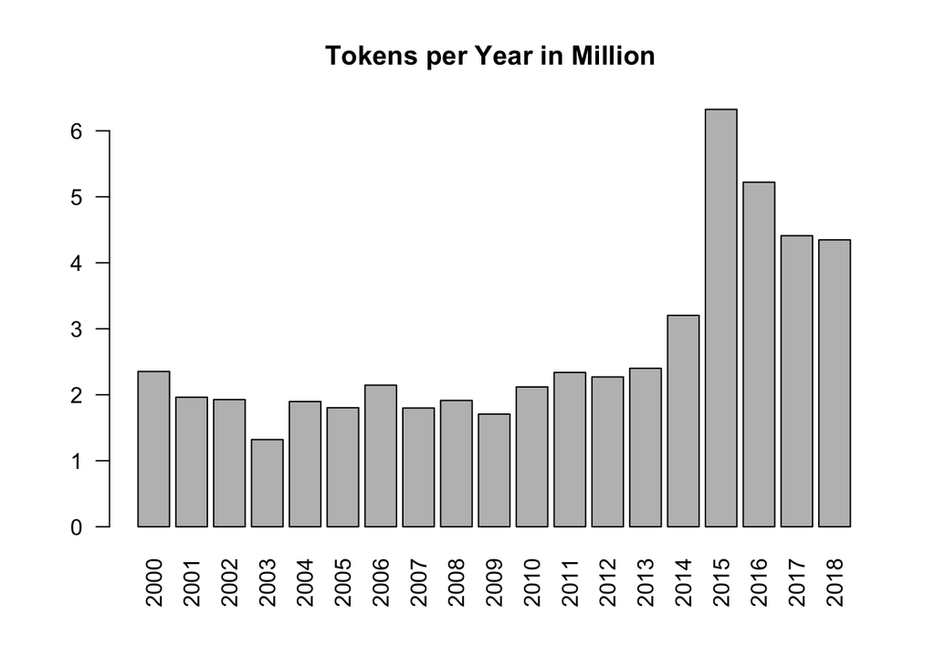

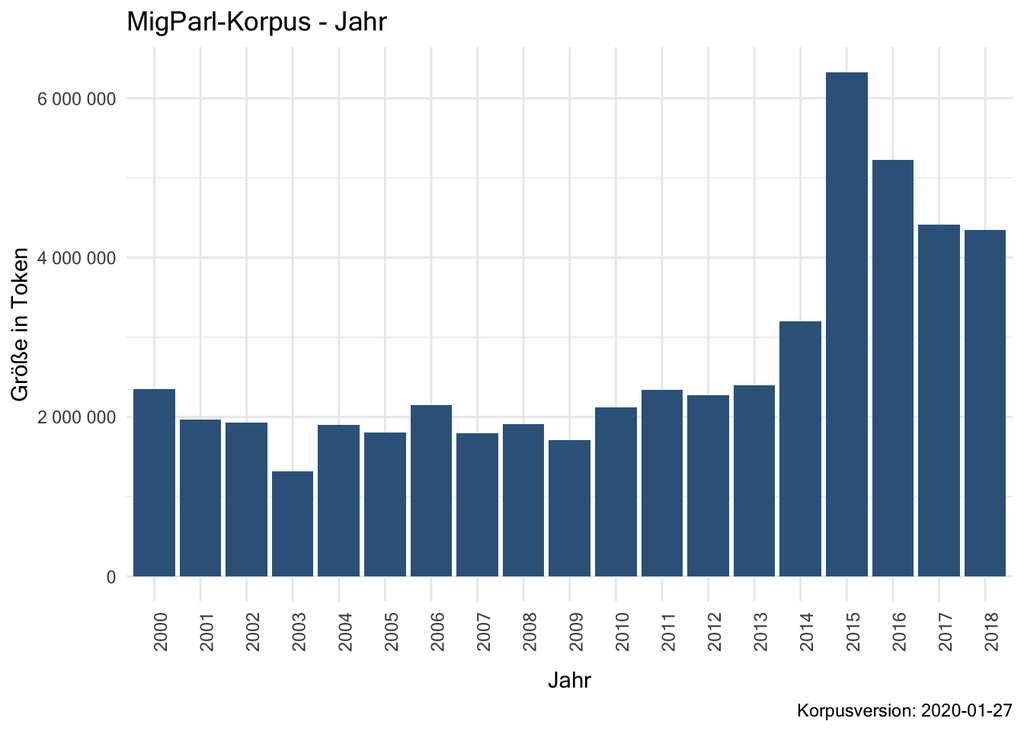

```r
barplot(
  height = dt_year[["size"]]/1000000,
  names.arg = dt_year[["year"]],
  las = 2,
  main = sprintf("Tokens per Year in Million ", target)
  )
```

### Structural Attribute “calendar_week”

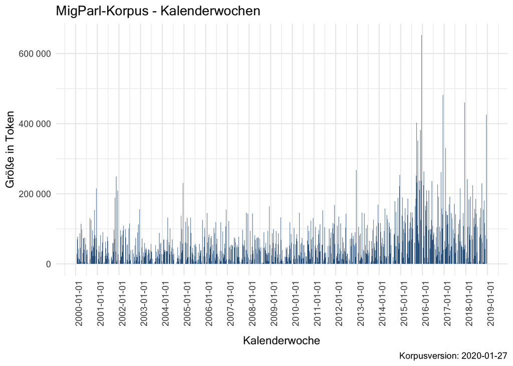

### Structural Attribute “party”

```r
DT::datatable(as.data.frame(size(target, s_attribute = "party")))
```

|  | party | size |
| --- | --- | --- |
| 1 | AfD | 2124500 |
| 2 | BIW | 47574 |
| 3 | Bürger für Mecklenburg-Vorpommern | 46719 |
| 4 | CDU | 13020088 |
| 5 | CSU | 1976345 |
| 6 | DSU | 879 |
| 7 | DVU | 353610 |
| 8 | FDP | 4150974 |
| 9 | FDP\|FREIE WAEHLER | 916 |
| 10 | FREIE WAEHLER | 335114 |

[output cut: 21 more lines]

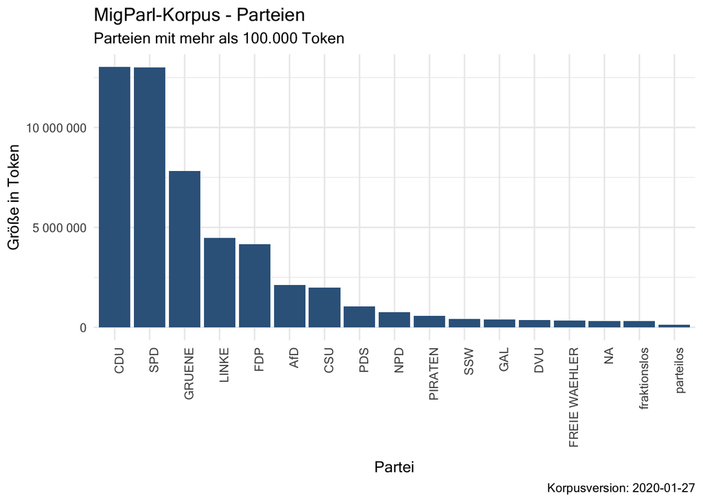

### Structural Attribute “role”

```r
dt_role <- size(target, s_attribute = "role")
DT::datatable(dt_role)
```

|  | role | size |
| --- | --- | --- |
| 1 | government | 11191795 |
| 2 | mp | 38005139 |
| 3 | presidency | 2273773 |

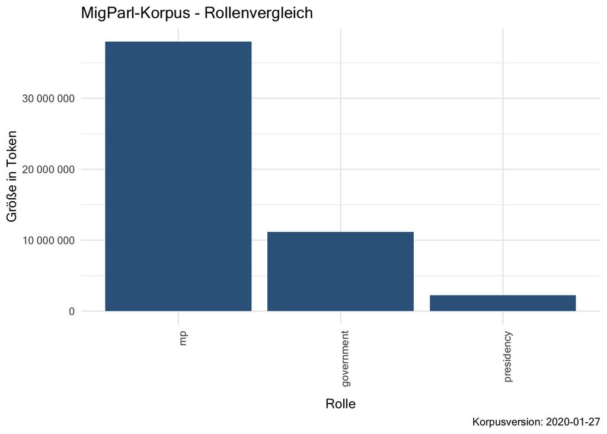

### Structural Attribute “speaker”

```r
DT::datatable(size(target, s_attribute = "speaker"))
```

|  | speaker | size |
| --- | --- | --- |
| 1 | Adelheid Rupp | 1187 |
| 2 | Adi Sprinkart | 487 |
| 3 | Adolf Braun | 1787 |
| 4 | Adolf Dinglreiter | 1902 |
| 5 | Adolf Kessel | 35047 |
| 6 | Adolf Spotka | 1253 |
| 7 | Adolf Weiland | 756 |
| 8 | Adrian Grasse | 656 |
| 9 | Adrian Mohr | 3711 |
| 10 | Ajibola Olalowo | 2104 |

[output cut: 3667 more lines]

### Structural Attribute “regional_state”

```r
rs_dt <- size(target, s_attribute = "regional_state")
DT::datatable(rs_dt)
```

|  | regional_state | size |
| --- | --- | --- |
| 1 | BB | 1909575 |
| 2 | BE | 3109974 |
| 3 | BW | 3399109 |
| 4 | BY | 4091021 |
| 5 | HB | 3073804 |
| 6 | HE | 5077787 |
| 7 | HH | 2601390 |
| 8 | MV | 3082076 |
| 9 | NI | 4269479 |
| 10 | NW | 4236904 |

[output cut: 6 more lines]

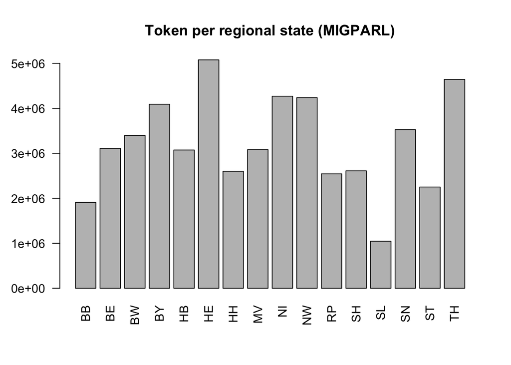

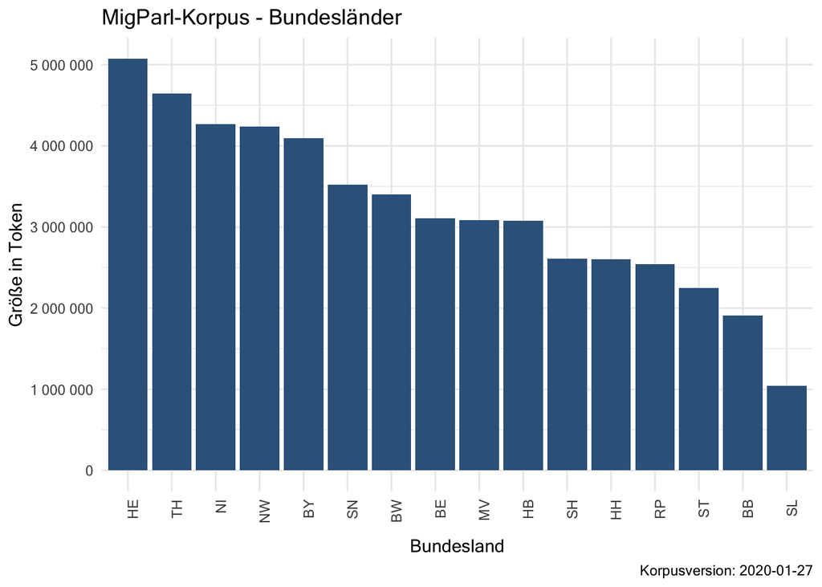

```r
barplot(
  height = rs_dt[["size"]],
  names.arg = rs_dt[["regional_state"]],
  las = 2,
  main = sprintf("Token per regional state (%s)", target)
  )
```

Speeches are sampled with two different approaches which are described in detail in other parts of the `MigParl` documentation. Here, the consequences of these different sampling techniques should be illustrated in one graph. The year overview shown earlier is appended to account for the origin of the speech.

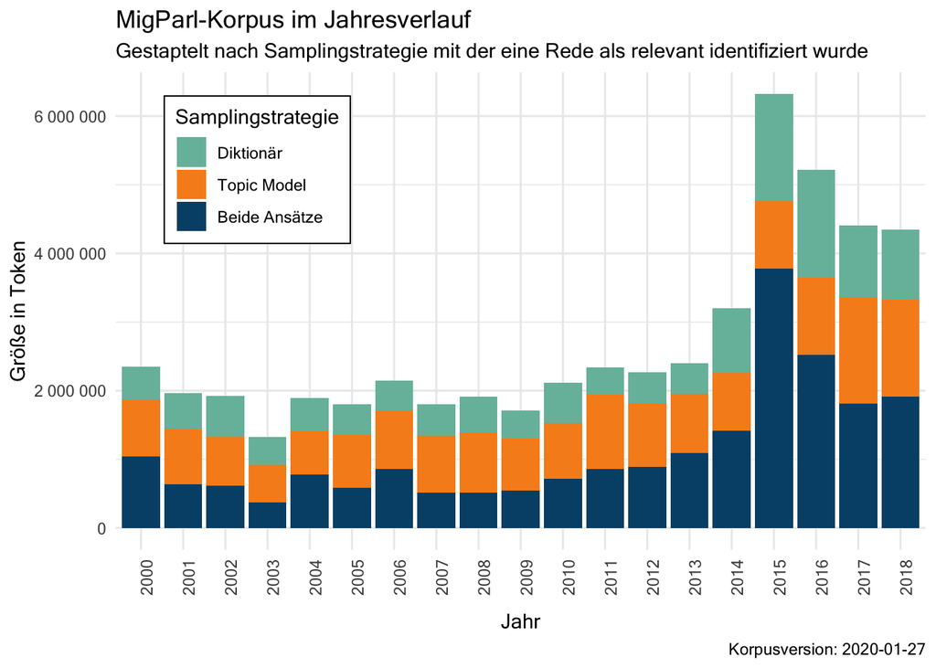